# Evaluating the Mechanisms for Missing Data in the Enhanced Tuberculosis Surveillance System

# Results

## Data completeness

We found high completeness for common demographic variables such as sex, age, ethnic group and UK birth status (Figure 1, Table 1). More problematically, BCG status and year of BCG status had a high percentage missing, even after accounting for the introduction of national collection of these variables in 2008.[2] Socio-economic status (as national quintiles) was not collected until 2010 but after this point is highly complete.[2] Comparing pre 2009 and post 2008 in Table 1 (Figure 1) we see completeness changes over time.[2,6] Figure 1 also indicates that there are multiple groups of variables that share a correlated pattern of missing data.

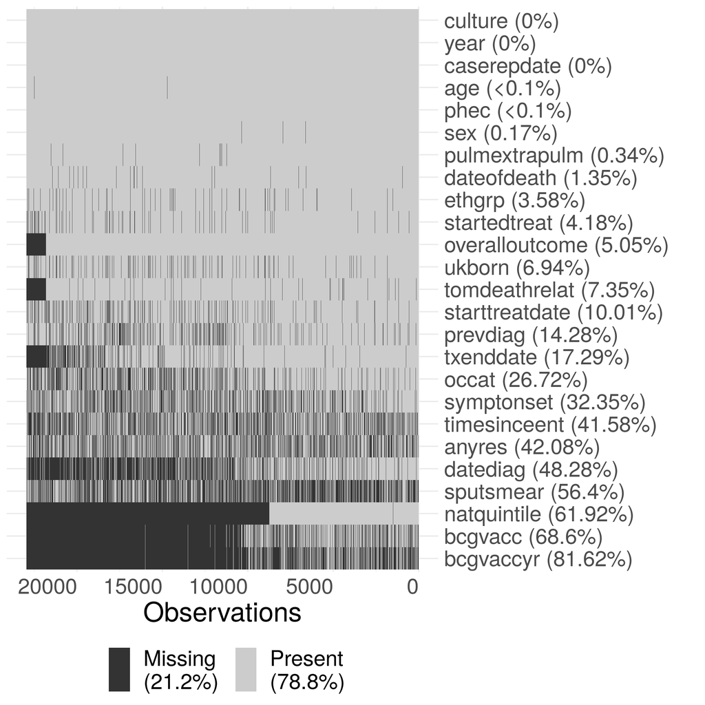

Figure 1: Summary plot of missing data in the extract of the ETS data used in this thesis. Due to the large size of the dataset, the data has been sub-sampled with only 20% of the data shown in this figure. Notifications have been ordered by date of notification from left to right. The following subset of variables are shown: year (year), sex (sex), age (age), PHE Centre (phec), Occupation (occat), Ethnic group (ethgrp), UK birth status (ukborn), Time since entry (timesinceent), date of symptom onset (symptonset), date of diagnosis (datediag), started treatment (startedtreat), date of starting treatment (starttreatdate), treatment end date (txenddate), pulmonary or extra-pulmonary TB (pulmextrapulm), culture (culture), sputum smear status (sputsmear), drug resistance (anyres), previous diagnosis (prevdiag), BCG status(bcgvacc), Year of BCG vaccination (bcgvaccyr), overall outcome (overalloutcome), cause of death (tomdeathrelate), socio-economic status quintiles (natquintile), and date of death (dateofdeath). Nested variables have been accounted for (i.e date of death has had an entry added for cases that are known to have not died), so that true missingness for all variables is estimated.

Table 1: Breakdown of missing data from the ETS prior to the web based system (pre 2009) and post (post 2008) by variable, ordered by the percentage missing for a subset of variables. The following subset of variables are shown year (year), sex (sex), age (age), PHE Centre (phec), Occupation (occat), Ethnic group (ethgrp), UK birth status (ukborn), Time since entry (timesinceent), date of symptom onset (symptonset), date of diagnosis (datediag), started treatment (startedtreat), date of starting treatment (starttreatdate), treatment end date (txenddate), pulmonary or extra-pulmonary TB (pulmextrapulm), culture (culture), sputum smear status (sputsmear), drug resistance (anyres), previous diagnosis (prevdiag), BCG status(bcgvacc), Year of BCG vaccination (bcgvaccyr), overall outcome (overalloutcome), cause of death (tomdeathrelate), socio-economic status quintiles (natquintile), and date of death (dateofdeath). Nested variables have been accounted for (i.e data of death has had an entry added for cases that are known to have not died), so that true missingness for all variables is estimated.

| Variable | Missing (N) | Missing (%) | Missing (N) | Missing (%) |
| --- | --- | --- | --- | --- |
| natquintile | 63175 | 100.0 | 8120 | 15.7 |
| bcgvaccyr | 62479 | 98.9 | 31421 | 60.8 |
| bcgvacc | 61916 | 98.0 | 17133 | 33.2 |
| datediag | 45557 | 72.1 | 10303 | 19.9 |
| sputsmear | 32912 | 52.1 | 32094 | 62.1 |
| timesinceent | 29084 | 46.0 | 18670 | 36.2 |
| anyres | 27485 | 43.5 | 20995 | 40.7 |
| occat | 24870 | 39.4 | 5513 | 10.7 |
| symptonset | 23937 | 37.9 | 12829 | 24.8 |
| txenddate | 18711 | 29.6 | 1137 | 2.2 |
| prevdiag | 13204 | 20.9 | 3148 | 6.1 |
| starttreatdate | 9151 | 14.5 | 2127 | 4.1 |
| tomdeathrelat | 7539 | 11.9 | 1191 | 2.3 |
| ukborn | 6230 | 9.9 | 1825 | 3.5 |
| overalloutcome | 6044 | 9.6 | 0 | 0.0 |
| startedtreat | 4242 | 6.7 | 602 | 1.2 |
| ethgrp | 2811 | 4.4 | 1229 | 2.4 |
| dateofdeath | 1235 | 2.0 | 357 | 0.7 |
| pulmextrapulm | 177 | 0.3 | 213 | 0.4 |
| sex | 101 | 0.2 | 110 | 0.2 |
| phec | 32 | 0.1 | 0 | 0.0 |
| age | 25 | 0.0 | 0 | 0.0 |
| caserepdate | 0 | 0.0 | 0 | 0.0 |
| year | 0 | 0.0 | 0 | 0.0 |
| culture | 0 | 0.0 | 0 | 0.0 |

By filtering nested variables - rather than by using replacement - we found the date of starting treatment was 5.9% (6434/108410) missing, which is more complete than previously estimated. For cases that were known to have completed treatment 16.5% (13804/83891) were missing a date for the end of treatment. In notifications that were known to have died, 26.6% (1592/5976) were missing the date of death and 44.9% (2686/5976) were missing the cause of death.